fossil

# MA-Networker, dug back up.

21 results: 1 exact, 4 agree, 7 partly agree, 1 inconclusive, 5 differ, 3 not attempted. MA-Networker was never released, so it was rebuilt from the paper and run on the same ChIP data and an expression library rebuilt from the SGD archive.

See every result

## Install manetworker

Python package

```
pip install "git+https://github.com/jeonglab-bcm/fossil#subdirectory=PMC407845/package"
```

Python 3.10 or later, with NumPy and SciPy.

[README](https://github.com/jeonglab-bcm/fossil/blob/main/PMC407845/package/README.md) [Tutorial](https://github.com/jeonglab-bcm/fossil/blob/main/PMC407845/package/tutorial/TUTORIAL.md)

## Fig. 1

Fig. 1. (b) Activity profiles of Hap4, Ndd1 and Ste12 over stress (red), pheromone (green) and cell cycle (blue) experiments. (c) ChIP binding log ratio against coupling for the same TFs: B- black, B+/C+ red, B+/C- green. Panel a is a diagram.

Differs

Published

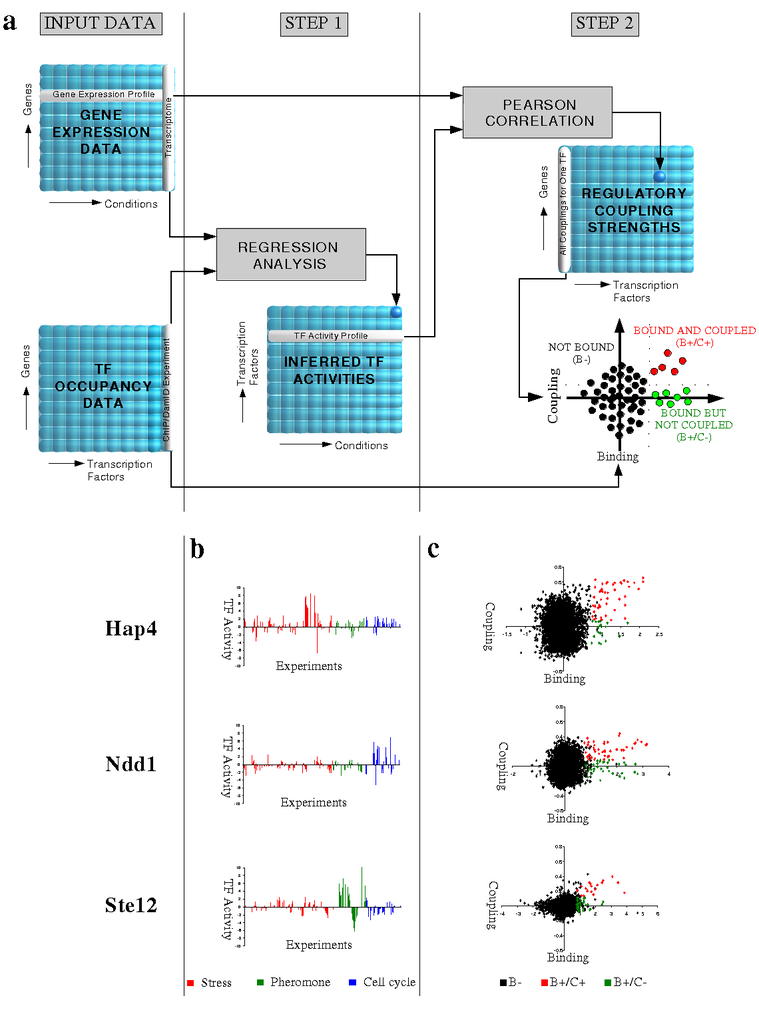

Our run

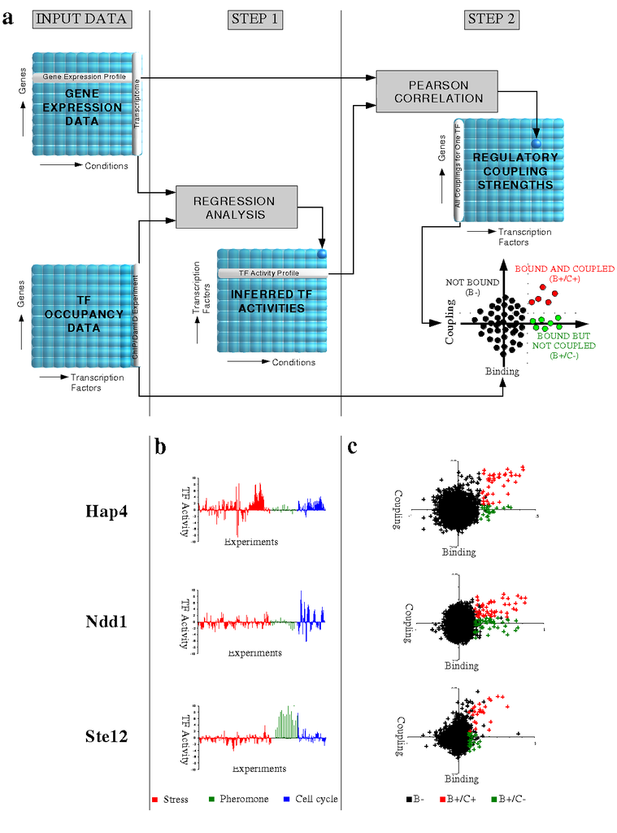

**Fig. 1b, activity profiles of Hap4, Ndd1 and Ste12**

3 of 3 values, Agrees

**Fig. 1c, Hap4 binding against coupling**

52.5% within 2 px, Partly agrees

**Fig. 1c, Ndd1 binding against coupling**

59.0% within 2 px, Inconclusive

**Fig. 1c, Ste12 binding against coupling**

27.5% within 2 px, Differs

Our B+/C+ (red) and B+/C- (green) points fall in the published places better than any control, but our couplings are larger in magnitude (r from -0.81 to 0.92; B+/C+ genes up to 0.71, against about 0.65 in the paper), so many of our points sit above the published ones. The rebuilt library (2010 reprocessing, 677 arrays) is the likely reason; it cannot be checked without the authors' 2003 library or coupling_result. Our coupling scaled by 0.9 scores better than ours, so the score cannot confirm our coupling scale for Ndd1: our couplings are larger in magnitude than the published ones, as for Hap4, although the split itself is close (50 B+/C+ and 44 B+/C- against 50 and 42). Our Ste12 couplings are much stronger than the published ones (our B+/C+ genes reach r 0.67; the paper's stop near 0.45), and we call 25 B+/C+ and 25 B+/C- against 19 and 31. Our pheromone experiments are 15 Roberts 2000 arrays, where the paper had 56; Ste12's activity is carried by them.

## Fig. 2

Fig. 2. Number of over-represented GO categories among the B+/C+ (red) and B+/C- (green) genes of each of the 37 TFs.

Partly agrees

Published

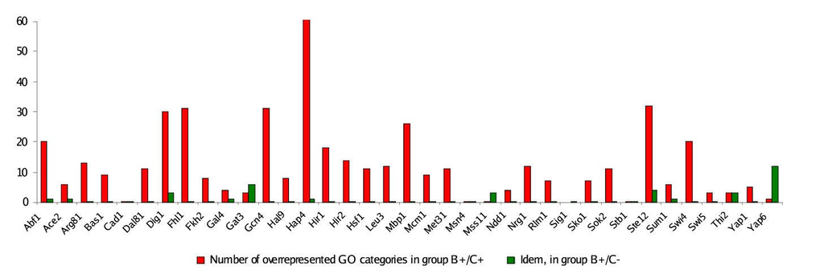

Our run

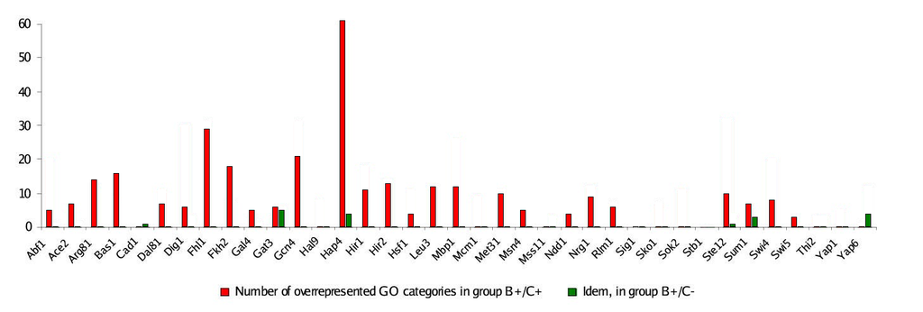

**Fig. 2, GO categories per TF**

29 of 73 values, Partly agrees

29 of 73 bars match exactly (24 of 37 B+/C- bars, mostly zeros). B+/C+ counts follow the coupling calls, the GO release (2004-03 against 2003-05) and the unstated correction; Stb1 is not in our model.

## Fig. 3

Fig. 3. Coupling scores (-log10 P) between TFs and the two genes of a shared divergent promoter.

Partly agrees

Published

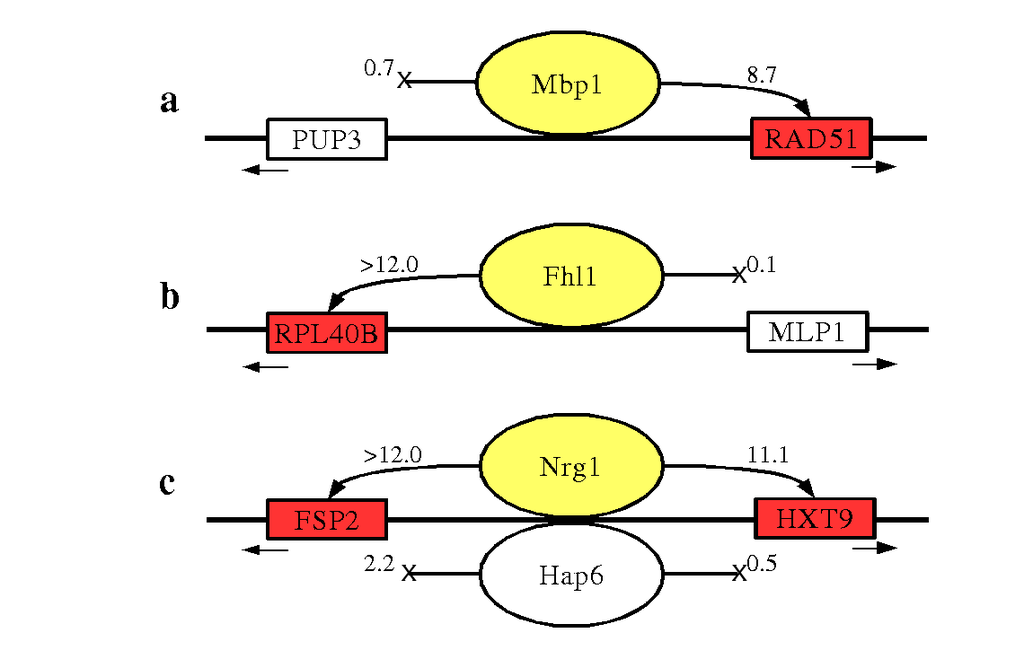

Our run

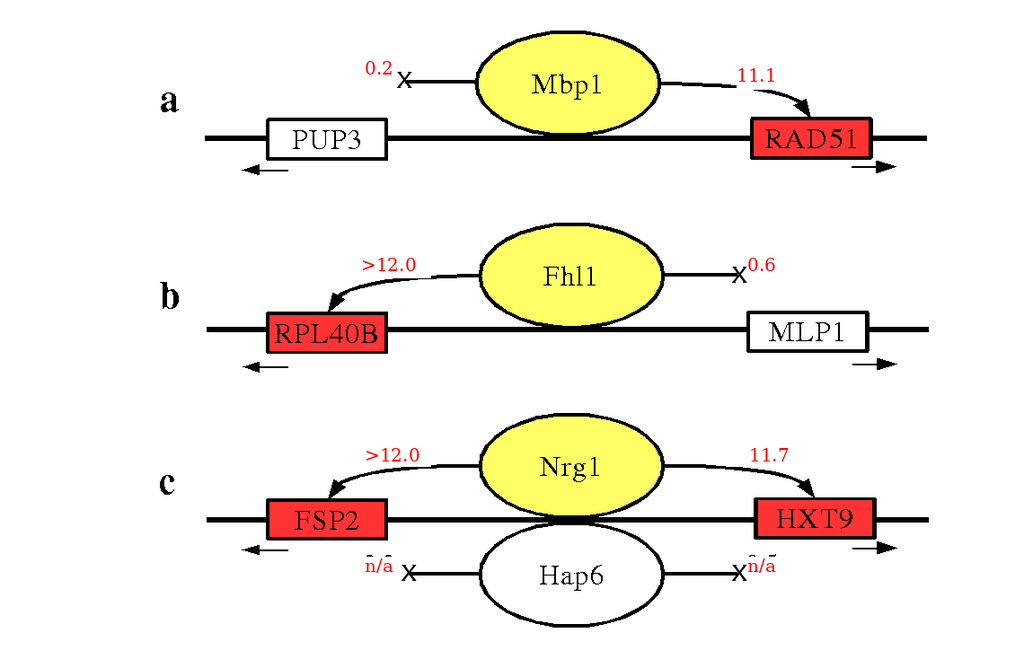

**Fig. 3, coupling scores at divergent promoters**

2 of 8 values, Partly agrees

Both scores above 12 come back, and every regulatory call of the figure is the same (RAD51, RPL40B, FSP2 and HXT9 coupled; PUP3 and MLP1 not), but the other printed scores differ (Mbp1 to RAD51 11.1 against 8.7), as our couplings are stronger throughout (see fig1c). Hap6 cannot be computed: it is not in the ChIP data.

## Every result

Every figure, table and claim of the paper. Values agree when they equal the paper at the precision it prints; Fig. 1c is scored by pixels against wrong-input and near-miss controls.

Result

Verdict

Measure

Why

Fig. 1a

Not attempted

A diagram of the method; there is nothing to recompute.

Text: 751 arrays and 113 TFs

Partly agrees

1 of 2 values

- expression arrays in the library: paper 751, ours **677**
- TFs with ChIP data: paper 113, ours **113**

The SGD archive holds 677 distinct arrays of the paper's 751. Casagrande 2000, Rutherford 2001 and Diehn 2000 (5 arrays) are not there; SGD keeps 15 of Roberts 2000's 56 arrays, 138 of Gasch 2000's 156 (replicates averaged), 55 of Spellman's 60 and 52 of Gasch 2001's 53; Yun 2000 and Protchenko 2001 share one file. All 113 TFs of Lee et al. are there.

Fig. 1b, activity profiles of Hap4, Ndd1 and Ste12

Agrees

3 of 3 values

- Hap4: group with the largest mean |activity|: paper stress, ours **stress**
- Ndd1: group with the largest mean |activity|: paper cell cycle, ours **cell cycle**
- Ste12: group with the largest mean |activity|: paper pheromone, ours **pheromone**

Fig. 1c, Hap4 binding against coupling

Partly agrees

52.5% within 2 px

Our B+/C+ (red) and B+/C- (green) points fall in the published places better than any control, but our couplings are larger in magnitude (r from -0.81 to 0.92; B+/C+ genes up to 0.71, against about 0.65 in the paper), so many of our points sit above the published ones. The rebuilt library (2010 reprocessing, 677 arrays) is the likely reason; it cannot be checked without the authors' 2003 library or coupling_result.

Fig. 1c, Ndd1 binding against coupling

Inconclusive

59.0% within 2 px

Our coupling scaled by 0.9 scores better than ours, so the score cannot confirm our coupling scale for Ndd1: our couplings are larger in magnitude than the published ones, as for Hap4, although the split itself is close (50 B+/C+ and 44 B+/C- against 50 and 42).

Fig. 1c, Ste12 binding against coupling

Differs

27.5% within 2 px

Our Ste12 couplings are much stronger than the published ones (our B+/C+ genes reach r 0.67; the paper's stop near 0.45), and we call 25 B+/C+ and 25 B+/C- against 19 and 31. Our pheromone experiments are 15 Roberts 2000 arrays, where the paper had 56; Ste12's activity is carried by them.

Text: 37 of 113 TFs kept by backward selection

Differs

0 of 2 values

- TFs kept by backward selection (of 113): paper 37, ours **63**
- the paper's 37 TFs among those kept: paper 37, ours **36**

Backward selection at the paper's P = 0.005/751 keeps 63 TFs, among them 36 of the paper's 37 (Stb1 is dropped). The paper's TFs head our ranking (our 18 most significant TFs are all among them), so our P-values are stronger overall rather than ordered differently; the reprocessed, imputed library is the likely reason.

Table 1

Partly agrees

12 of 148 values

- Abf1 B-: paper 5638, ours **5702**
- Abf1 B+/C+: paper 138, ours **133**
- Abf1 B+/C-: paper 136, ours **137**
- Abf1 unclassified: paper 470, ours **387**
- Ace2 B-: paper 5843, ours **5905**
- Ace2 B+/C+: paper 33, ours **34**
- Ace2 B+/C-: paper 33, ours **35**
- Ace2 unclassified: paper 473, ours **385**
- Arg81 B-: paper 5985, ours **6051**
- Arg81 B+/C+: paper 11, ours **10**
- Arg81 B+/C-: paper 10, ours **9**
- Arg81 unclassified: paper 376, ours **289**
- Bas1 B-: paper 5975, ours **6039**
- Bas1 B+/C+: paper 28, ours **22**
- Bas1 B+/C-: paper 13, ours **19**
- Bas1 unclassified: paper 366, ours **279**
- Cad1 B-: paper 5854, ours **5913**
- Cad1 B+/C+: paper 26, ours **26**
- Cad1 B+/C-: paper 13, ours **13**
- Cad1 unclassified: paper 489, ours **407**
- Dal81 B-: paper 5823, ours **5886**
- Dal81 B+/C+: paper 24, ours **24**
- Dal81 B+/C-: paper 16, ours **14**
- Dal81 unclassified: paper 519, ours **435**
- Dig1 B-: paper 5872, ours **5936**
- Dig1 B+/C+: paper 20, ours **25**
- Dig1 B+/C-: paper 11, ours **6**
- Dig1 unclassified: paper 479, ours **392**
- Fhl1 B-: paper 5754, ours **5806**
- Fhl1 B+/C+: paper 146, ours **151**
- Fhl1 B+/C-: paper 37, ours **40**
- Fhl1 unclassified: paper 445, ours **362**
- Fkh2 B-: paper 5261, ours **5320**
- Fkh2 B+/C+: paper 61, ours **72**
- Fkh2 B+/C-: paper 45, ours **35**
- Fkh2 unclassified: paper 1015, ours **932**
- Gal4 B-: paper 5149, ours **5201**
- Gal4 B+/C+: paper 20, ours **28**
- Gal4 B+/C-: paper 20, ours **12**
- Gal4 unclassified: paper 1193, ours **1118**
- Gat3 B-: paper 5891, ours **5957**
- Gat3 B+/C+: paper 40, ours **31**
- Gat3 B+/C-: paper 29, ours **33**
- Gat3 unclassified: paper 422, ours **338**
- Gcn4 B-: paper 5919, ours **5984**
- Gcn4 B+/C+: paper 58, ours **56**
- Gcn4 B+/C-: paper 21, ours **23**
- Gcn4 unclassified: paper 384, ours **296**
- Hal9 B-: paper 5948, ours **6011**
- Hal9 B+/C+: paper 4, ours **6**
- Hal9 B+/C-: paper 13, ours **9**
- Hal9 unclassified: paper 417, ours **333**
- Hap4 B-: paper 5939, ours **6002**
- Hap4 B+/C+: paper 47, ours **42**
- Hap4 B+/C-: paper 21, ours **27**
- Hap4 unclassified: paper 375, ours **288**
- Hir1 B-: paper 5963, ours **6025**
- Hir1 B+/C+: paper 19, ours **19**
- Hir1 B+/C-: paper 10, ours **10**
- Hir1 unclassified: paper 390, ours **305**
- Hir2 B-: paper 5932, ours **5991**
- Hir2 B+/C+: paper 8, ours **9**
- Hir2 B+/C-: paper 13, ours **12**
- Hir2 unclassified: paper 429, ours **347**
- Hsf1 B-: paper 5929, ours **5992**
- Hsf1 B+/C+: paper 35, ours **39**
- Hsf1 B+/C-: paper 17, ours **14**
- Hsf1 unclassified: paper 401, ours **314**
- Leu3 B-: paper 5988, ours **6053**
- Leu3 B+/C+: paper 8, ours **11**
- Leu3 B+/C-: paper 13, ours **9**
- Leu3 unclassified: paper 373, ours **286**
- Mbp1 B-: paper 5641, ours **5697**
- Mbp1 B+/C+: paper 65, ours **74**
- Mbp1 B+/C-: paper 40, ours **33**
- Mbp1 unclassified: paper 636, ours **555**
- Mcm1 B-: paper 5709, ours **5772**
- Mcm1 B+/C+: paper 42, ours **40**
- Mcm1 B+/C-: paper 46, ours **48**
- Mcm1 unclassified: paper 585, ours **499**
- Met31 B-: paper 5983, ours **6047**
- Met31 B+/C+: paper 15, ours **15**
- Met31 B+/C-: paper 13, ours **13**
- Met31 unclassified: paper 371, ours **284**
- Msn4 B-: paper 5952, ours **6015**
- Msn4 B+/C+: paper 23, ours **21**
- Msn4 B+/C-: paper 7, ours **8**
- Msn4 unclassified: paper 400, ours **315**
- Mss11 B-: paper 4735, ours **4780**
- Mss11 B+/C+: paper 11, ours **13**
- Mss11 B+/C-: paper 9, ours **7**
- Mss11 unclassified: paper 1627, ours **1559**
- Ndd1 B-: paper 5799, ours **5862**
- Ndd1 B+/C+: paper 50, ours **50**
- Ndd1 B+/C-: paper 42, ours **44**
- Ndd1 unclassified: paper 491, ours **403**
- Nrg1 B-: paper 5912, ours **5974**
- Nrg1 B+/C+: paper 61, ours **62**
- Nrg1 B+/C-: paper 20, ours **18**
- Nrg1 unclassified: paper 389, ours **305**
- Rlm1 B-: paper 5900, ours **5957**
- Rlm1 B+/C+: paper 13, ours **16**
- Rlm1 B+/C-: paper 24, ours **22**
- Rlm1 unclassified: paper 445, ours **364**
- Sig1 B-: paper 5683, ours **5739**
- Sig1 B+/C+: paper 0, ours **0**
- Sig1 B+/C-: paper 0, ours **0**
- Sig1 unclassified: paper 699, ours **620**
- Sko1 B-: paper 5155, ours **5207**
- Sko1 B+/C+: paper 2, ours **1**
- Sko1 B+/C-: paper 0, ours **1**
- Sko1 unclassified: paper 1225, ours **1150**
- Sok2 B-: paper 4881, ours **4927**
- Sok2 B+/C+: paper 10, ours **6**
- Sok2 B+/C-: paper 6, ours **9**
- Sok2 unclassified: paper 1485, ours **1417**
- Stb1 B-: paper 5791, ours **None**
- Stb1 B+/C+: paper 13, ours **None**
- Stb1 B+/C-: paper 10, ours **None**
- Stb1 unclassified: paper 568, ours **None**
- Ste12 B-: paper 5725, ours **5786**
- Ste12 B+/C+: paper 19, ours **25**
- Ste12 B+/C-: paper 31, ours **25**
- Ste12 unclassified: paper 607, ours **523**
- Sum1 B-: paper 5919, ours **5979**
- Sum1 B+/C+: paper 35, ours **36**
- Sum1 B+/C-: paper 26, ours **26**
- Sum1 unclassified: paper 402, ours **318**
- Swi4 B-: paper 5528, ours **5580**
- Swi4 B+/C+: paper 75, ours **84**
- Swi4 B+/C-: paper 48, ours **45**
- Swi4 unclassified: paper 731, ours **650**
- Swi5 B-: paper 5358, ours **5418**
- Swi5 B+/C+: paper 47, ours **40**
- Swi5 B+/C-: paper 45, ours **54**
- Swi5 unclassified: paper 932, ours **847**
- Thi2 B-: paper 5940, ours **6003**
- Thi2 B+/C+: paper 5, ours **5**
- Thi2 B+/C-: paper 1, ours **0**
- Thi2 unclassified: paper 436, ours **351**
- Yap1 B-: paper 5959, ours **6024**
- Yap1 B+/C+: paper 28, ours **27**
- Yap1 B+/C-: paper 16, ours **17**
- Yap1 unclassified: paper 379, ours **291**
- Yap6 B-: paper 5924, ours **5991**
- Yap6 B+/C+: paper 33, ours **26**
- Yap6 B+/C-: paper 54, ours **58**
- Yap6 unclassified: paper 371, ours **284**

Bound (B+) totals agree within 8 genes for every TF (the same ChIP file), but our run calls more bound genes coupled (59% per TF against 58%, with larger per-TF differences), Stb1 is not in our model, and our B- column is 45 to 67 genes above the paper and the unclassified column 68 to 88 below, because the paper's gene list (6382) and its expression filter are not stated.

Text: on average 58% of bound genes couple

Differs

0 of 1 values

- mean share of bound genes that couple (%): paper 58, ours **59**

59.0% in our run (59.1% pooled), against 58% (58.4% per TF from Table 1). The share follows the coupling calls of Table 1.

Claims recomputed from the paper's own tables

Agrees

Fig. 2, GO categories per TF

Partly agrees

29 of 73 values

29 of 73 bars match exactly (24 of 37 B+/C- bars, mostly zeros). B+/C+ counts follow the coupling calls, the GO release (2004-03 against 2003-05) and the unstated correction; Stb1 is not in our model.

Text: no GO enrichment in most B+/C- groups

Agrees

2 of 2 values

- no enriched GO category in most B+/C- groups: paper yes, ours **yes**
- B+/C+ groups enriched more often than B+/C- groups: paper yes, ours **yes**

Table 2, deletion response

Not attempted

The text says Table 2 averages Hughes et al.'s mutant/wild-type log ratios, but its genome-wide means (0.52 to 0.83, SD 0.12 to 0.34) are not log ratios: the genome-wide mean of the log10 ratios is 0.00 (SD 0.05 to 0.17) and of their absolute values 0.03 to 0.11. The values fit Hughes et al.'s per-gene P-values, which are not public (the Rosetta download sits behind a registration form; the SGD file has ratios only). The claim the table supports is checked from the ratios as text.deletion.

Text: B+/C+ genes respond to TF deletion, B+/C- mostly not

Partly agrees

1 of 2 values

- B+/C+ genes respond to the deletion (P < 0.05), TFs of 7: paper 7, ours **6**
- B+/C- response insignificant for most TFs: paper yes, ours **yes**

B+/C+ genes respond for 6 of 7 TFs in our run (Yap1: P = 0.13); B+/C- do not respond for any of the 7, so the claim's second half holds. The paper tested Hughes et al.'s P-values (see table2), which are not public.

Table 3, cell cycle motifs

Partly agrees

1 of 20 values

- MCB Mbp1 B+/C+: paper 38.4, ours **43.1**
- MCB Mbp1 B+/C-: paper 8.3, ours **5.8**
- MCB Swi4 B+/C+: paper 8.2, ours **7.8**
- MCB Swi4 B+/C-: paper 0.0, ours **0.1**
- SCB Mbp1 B+/C+: paper 7.0, ours **11.8**
- SCB Mbp1 B+/C-: paper 1.3, ours **2.2**
- SCB Swi4 B+/C+: paper 19.1, ours **35.6**
- SCB Swi4 B+/C-: paper 2.8, ours **3.1**
- Swi5p Ace2 B+/C+: paper 5.1, ours **5.8**
- Swi5p Ace2 B+/C-: paper 0.6, ours **0.8**
- Swi5p Swi5 B+/C+: paper 2.6, ours **5.6**
- Swi5p Swi5 B+/C-: paper 0.8, ours **0.1**
- SFF Fkh2 B+/C+: paper 12.9, ours **16.7**
- SFF Fkh2 B+/C-: paper 1.8, ours **4.2**
- SFF Mcm1 B+/C+: paper 3.1, ours **2.4**
- SFF Mcm1 B+/C-: paper 1.4, ours **2.6**
- SFF Ndd1 B+/C+: paper 8.3, ours **6.0**
- SFF Ndd1 B+/C-: paper 0.6, ours **2.0**
- SFF Swi4 B+/C+: paper 3.5, ours **3.4**
- SFF Swi4 B+/C-: paper 0.1, ours **0.1**

1 of 20 values matches at printed precision, but the pattern holds: the same motifs are strongly enriched in the same B+/C+ groups (MCB in Mbp1 43.1 against 38.4; SFF in Fkh2 16.7 against 12.9), and far less in B+/C-. The genome release, the cutting of upstream regions, strand handling and the binomial's unit are not stated.

Text: motif enrichment in B+/C- always far below B+/C+

Differs

0 of 1 values

- B+/C- enrichment below B+/C+ in every case: paper yes, ours **no**

9 of 10 combinations hold in our run; SFF in Mcm1 gives 2.4 for B+/C+ and 2.6 for B+/C- (the paper: 3.1 and 1.4). With forward-strand counts, or with genes carrying the motif instead of counts, all 10 hold: the claim turns on how motifs are counted, which the paper does not state.

Text: 85% overlap with B+/C+ groups from Simon et al.

Differs

0 of 1 values

- mean overlap of B+/C+ groups, Simon et al. against Lee et al. (%): paper 85, ours **83**

83% in our run against 85%. The overlap measure is not stated; as a share of the Lee groups it comes closest.

Text: 1592 of 4532 probes shared by divergent genes

Exact

2 of 2 values

- ChIP probes shared by divergently transcribed genes: paper 1592, ours **1592**
- ChIP probes in all: paper 4532, ours **4532**

Fig. 3, coupling scores at divergent promoters

Partly agrees

2 of 8 values

- Mbp1 to RAD51: paper 8.7, ours **11.1**
- Mbp1 to PUP3: paper 0.7, ours **0.2**
- Fhl1 to RPL40B: paper >12.0, ours **>12.0**
- Fhl1 to MLP1: paper 0.1, ours **0.6**
- Nrg1 to FSP2: paper >12.0, ours **>12.0**
- Nrg1 to HXT9: paper 11.1, ours **11.7**
- Hap6 to FSP2: paper 2.2, ours **None**
- Hap6 to HXT9: paper 0.5, ours **None**

Both scores above 12 come back, and every regulatory call of the figure is the same (RAD51, RPL40B, FSP2 and HXT9 coupled; PUP3 and MLP1 not), but the other printed scores differ (Mbp1 to RAD51 11.1 against 8.7), as our couplings are stronger throughout (see fig1c). Hap6 cannot be computed: it is not in the ChIP data.

Table 4, deletion in place of coupling

Not attempted

D+ needs Hughes et al.'s per-gene P-values (P < 1e-2), which are not public. The table is also inconsistent with itself: its Dig1 row sums to 6027 genes and the other six to 6067, while every Table 1 row sums to 6382.

Python package manetworker and its tutorial

Agrees

The main claim nearly comes back: 59% of bound genes couple in our run, against the paper's 58%. The validations point the same way as the paper's. The numbers differ because the expression library was rebuilt (677 of 751 arrays, reprocessed in 2010), because GO and motif settings are not stated, and because Hughes et al.'s P-values, behind Table 2 and Table 4, are not public.

## What came back

**The method**

MA-Networker as the Python package manetworker: regression, backward selection, coupling and the false discovery rate, from the paper's Methods.

**Fig. 1b**

Hap4 moves most in stress, Ndd1 in the cell cycle, Ste12 with pheromone, as the caption says.

**Table 1**

Bound genes per TF within 8 of the paper's for every TF; 59% of them couple against 58%.

**Divergent promoters**

1592 of 4532 ChIP probes shared by two genes, exactly as printed.

**Fig. 2**

The vector bars read exactly from the paper's own file; most B+/C- groups have no enriched GO category, as in the paper.

**Fig. 3**

Every coupling call of the figure is the same; both scores above 12 come back.

## What stayed buried

- The authors' 751-array library: 74 arrays are not in the SGD archive, and the rest were reprocessed in 2010.
- The authors' released activity and coupling files: their site refuses scripted downloads and the web archive was out of reach from this run.
- Table 2 and Table 4: they rest on Hughes et al.'s per-gene P-values, which sit behind a registration form. Table 2's numbers are those P-values, not the log ratios the text names.
- Hap6 in Fig. 3: it is not among the 113 TFs of the ChIP data.

The main claim nearly comes back: 59% of bound genes couple in our run, against the paper's 58%. The validations point the same way as the paper's. The numbers differ because the expression library was rebuilt (677 of 751 arrays, reprocessed in 2010), because GO and motif settings are not stated, and because Hughes et al.'s P-values, behind Table 2 and Table 4, are not public.

## What we matched

How each part of the paper's method was rebuilt.

**ChIP data**

Lee et al. 2002, 113 TFs, the file the paper used; bound means P below 0.001.

**Expression**

677 arrays from 15 of the paper's 19 sources, from the SGD archive, as log2 ratios.

**Step 1**

A regression per array on all TFs; backward selection at P = 0.005/751.

**Step 2**

Pearson correlation of each gene with each activity profile; 5% false discovery rate.

**Validation**

GO release 2004-03 (the oldest archived), Hughes 2000 deletions, the S288C genome, Simon et al. 2001 ChIP.

## The session

The reproduction was done by an AI agent, Claude Code, in one session. Every prompt, reply and tool call of it is published.

**Wall clock**

50 min

first message to last, waits included

**Human prompts**

5

messages typed by a person

**Tool calls**

215

none in subagents

**Tokens**

50.9 M

every request, subagents included

Read the session [The raw files](https://github.com/jeonglab-bcm/fossil/tree/main/PMC407845/session)